# Regression Analysis and Model Validation

## A. Data wrangling

Data wrangling is an important step in data analysis. This includes gathering, inspecting, transforming and mapping the data into a appropriate format for a variety of data analyses.

### a.1 Demo data sets

First step is to laod the data to the console. The data set that will be using for can be accessed using this link ‘http://www.helsinki.fi/~kvehkala/JYTmooc/JYTOPKYS3-data.txt’. Information about the data set can be acessed through this link: ‘https://www.mv.helsinki.fi/home/kvehkala/JYTmooc/JYTOPKYS3-meta.txt’.

After loading the data we can check the dimension and structure of the data using **dim()** and **str()**, respectively.

```r
date()
```

```
## [1] "Fri Nov 06 15:32:06 2020"
```

```r
# installing packages

#install.packages(c('dplyr', 'ggplot2'))
library(dplyr)
library(GGally)
library(ggplot2)

# Read the data
data <- read.table("http://www.helsinki.fi/~kvehkala/JYTmooc/JYTOPKYS3-data.txt", sep = "\t", header = TRUE)

# Inspect the dimension and structure of the data
dim(data)
```

```
## [1] 183  60
```

```r
str(data)
```

```
## 'data.frame':    183 obs. of  60 variables:
##  $ Aa      : int  3 2 4 4 3 4 4 3 2 3 ...
##  $ Ab      : int  1 2 1 2 2 2 1 1 1 2 ...
##  $ Ac      : int  2 2 1 3 2 1 2 2 2 1 ...
##  $ Ad      : int  1 2 1 2 1 1 2 1 1 1 ...
##  $ Ae      : int  1 1 1 1 2 1 1 1 1 1 ...
##  $ Af      : int  1 1 1 1 1 1 1 1 1 2 ...
##  $ ST01    : int  4 4 3 3 4 4 5 4 4 4 ...
##  $ SU02    : int  2 2 1 3 2 3 2 2 1 2 ...
##  $ D03     : int  4 4 4 4 5 5 4 4 5 4 ...
##  $ ST04    : int  4 4 4 4 3 4 2 5 5 4 ...
##  $ SU05    : int  2 4 2 3 4 3 2 4 2 4 ...
##  $ D06     : int  4 2 3 4 4 5 3 3 4 4 ...
##  $ D07     : int  4 3 4 4 4 5 4 4 5 4 ...
##  $ SU08    : int  3 4 1 2 3 4 4 2 4 2 ...
```

[output cut: 46 more lines]

### a.2 Adding new columns

It is also possible to add new columns in the data set. In this exercise, we are going to create new column **attitude**, by scaling the column **data$attitude** by 10.

we are also adding new column (**attitude**, **deep**, **stra**, **surf**) corresponding to the mean value for questions related to deep, strategic and surface learning.

```r
#-- create 'attitude' column
data$attitude<-data$Attitude/10

#-- create 'deep' column for questions related to deep learning
deep_q<-c("D03", "D11", "D19", "D27", "D07", "D14",
          "D22", "D30","D06",  "D15", "D23", "D31")
deep_c<-select(data, one_of(deep_q))
data$deep<-rowMeans(deep_c)

#-- create 'stra' column for questions related to strategic learning
strategic_q <- c("ST01","ST09","ST17","ST25","ST04","ST12",
                         "ST20","ST28")

strategic_c<-select(data, one_of(strategic_q))
data$stra<-rowMeans(strategic_c)

#create 'surf' column for questions related to surface learning
surface_q <- c("SU02","SU10","SU18","SU26", "SU05","SU13",
                       "SU21","SU29","SU08","SU16","SU24","SU32")
surface_c<-select(data, one_of(surface_q))
data$surf<-rowMeans(surface_c)
```

### a.2 Subsetting data set

We can create a subset from the original data using **dplyr** package. We are going to creat a data set that only contains a subset of the originial data set and we are calling it **l2014**.

```r
library(dplyr)

#-- columns to keep
keep_columns <- c("gender","Age","attitude", "deep",
                  "stra", "surf", "Points")

#-- create a new dataset
l2014<-select(data, one_of(keep_columns))

#-- check structure
str(l2014)
```

```
## 'data.frame':    183 obs. of  7 variables:
##  $ gender  : chr  "F" "M" "F" "M" ...
##  $ Age     : int  53 55 49 53 49 38 50 37 37 42 ...
##  $ attitude: num  3.7 3.1 2.5 3.5 3.7 3.8 3.5 2.9 3.8 2.1 ...
##  $ deep    : num  3.58 2.92 3.5 3.5 3.67 ...
##  $ stra    : num  3.38 2.75 3.62 3.12 3.62 ...
##  $ surf    : num  2.58 3.17 2.25 2.25 2.83 ...
##  $ Points  : int  25 12 24 10 22 21 21 31 24 26 ...
```

### a.3 Data visualization

We are using **GGally** and **ggplot2** packages in creating a graphical overview of the data set we just created.

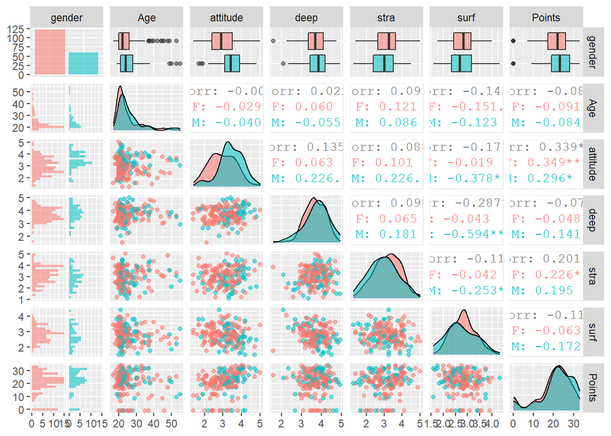

```r
library(GGally)
library(ggplot2)

#creating plot matrix using ggpairs

p <- ggpairs(l2014, mapping = aes(col = gender, alpha = 0.3),
             lower = list(combo = wrap("facethist", bins = 20)))

p
```

The graphical output is a scatter plot matrix among the parameters with colors corresponding to **gender**. There is gender biased in the data set, however the distribution is generally normal for both gender in all student’s attitude towards statistics and approaches to learning. In addition, age distribution is skewed towards younger participants between ages 20 - 30.

## B. Multiple Linear Regression

Linear regression is a statistical approach that demonstrates relationships between a dependent variable **y** and one or more explanatory variables **X**.

In this exercise, we are selecting three explanatory variables (attitude, stra, surf) from l2014 data set we created from the previous section to explain the exam points of the students.

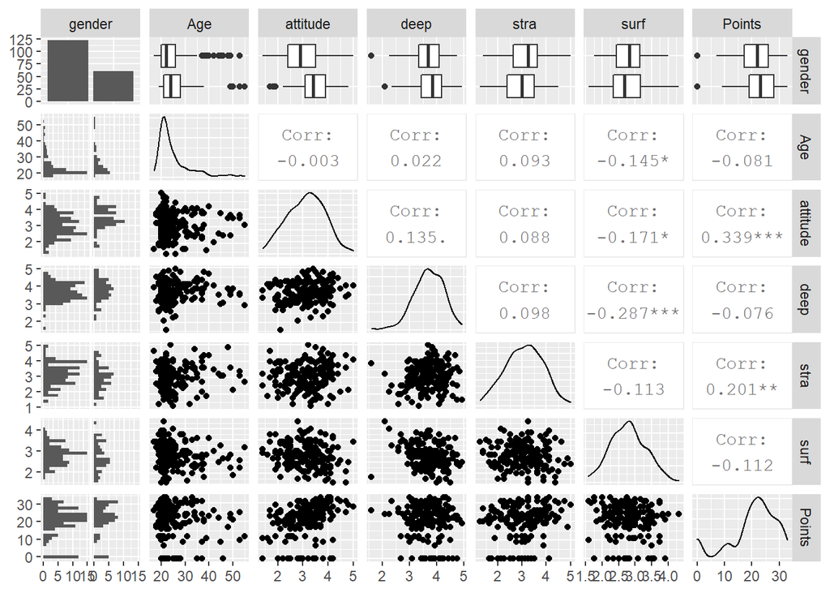

```r
#-- visualize the relationships
library(GGally)
library(ggplot2)

ggpairs(l2014, lower = list(combo = wrap("facethist", bins = 20)))
```

```r
#-- create a regression model with multiple explanatory variables
# lm <- the type of model we are using (linear model)
# points <- dependent variable
# attitude + stra + surf <- explanatory variables

m1 <- lm(Points~attitude + stra + surf, data = l2014)

#-- print out summary
summary(m1)
```

```
##
## Call:
## lm(formula = Points ~ attitude + stra + surf, data = l2014)
##
## Residuals:
##     Min      1Q  Median      3Q     Max
## -25.151  -3.212   2.233   5.257  13.694
##
## Coefficients:
##             Estimate Std. Error t value Pr(>|t|)
## (Intercept)   4.7781     5.1577   0.926   0.3555
## attitude      3.7570     0.8308   4.522 1.11e-05 ***
## stra          1.8968     0.7832   2.422   0.0164 *
## surf         -0.6262     1.1494  -0.545   0.5866
## ---
## Signif. codes:  0 '***' 0.001 '**' 0.01 '*' 0.05 '.' 0.1 ' ' 1
##
## Residual standard error: 8.082 on 179 degrees of freedom
## Multiple R-squared:  0.146,  Adjusted R-squared:  0.1317
## F-statistic:  10.2 on 3 and 179 DF,  p-value: 3.089e-06
```

Summary of the results from the first model (**m1**) shows that student’s **attitude** have significant statistical effect to their total exam points.

We can make another model, this time only including **attitude** as the explanatory variable of exam points.

```r
#-- model 2 with only 1 explanatory variabe
m2<-lm(Points~attitude, data = l2014)

#-- printing summary
summary(m2)
```

```
##
## Call:
## lm(formula = Points ~ attitude, data = l2014)
##
## Residuals:
##     Min      1Q  Median      3Q     Max
## -24.934  -2.716   1.883   5.180  13.289
##
## Coefficients:
##             Estimate Std. Error t value Pr(>|t|)
## (Intercept)   8.0926     2.6494   3.054   0.0026 **
## attitude      4.0099     0.8266   4.851 2.63e-06 ***
## ---
## Signif. codes:  0 '***' 0.001 '**' 0.01 '*' 0.05 '.' 0.1 ' ' 1
##
## Residual standard error: 8.182 on 181 degrees of freedom
## Multiple R-squared:  0.1151, Adjusted R-squared:  0.1102
## F-statistic: 23.54 on 1 and 181 DF,  p-value: 2.635e-06
```

However, model needs to be evaluated and check if it violates assumptions for linear regression.

## b.2 Model validation

Linear regression has several assumptions:  
+ errors are normally distributed  
+ errors are not correlated  
+ errors have constant variance  
+ the size of a given error does not depend on the explanatory variable

This assumptions can be visually inspected using **plot()** command.

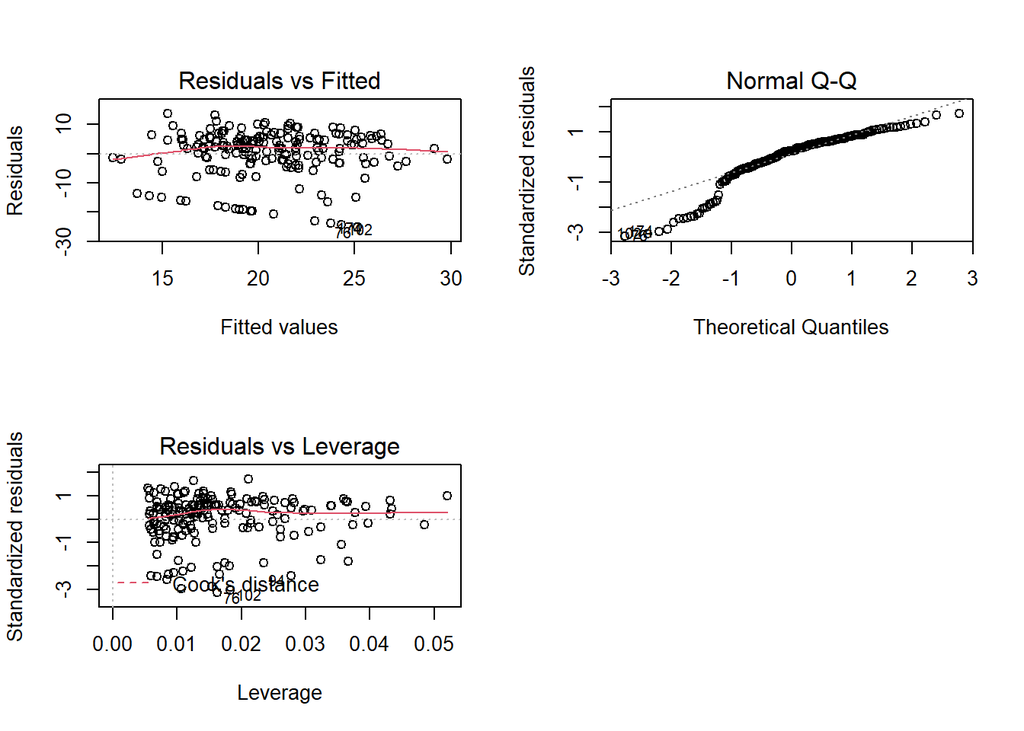

```r
# create a regression model with multiple explanatory variables
l2014<-as.data.frame(l2014)
m3=lm(Points ~ attitude + stra, data = l2014)
# draw diagnostic plots using the plot() function. Choose the plots 1, 2 and 5
par(mfrow = c(2,2))
plot(m3, which = c(1, 2, 5))
```